# Data Types

```r
library(tidyverse)
library(babynames)
library(nycflights13)
library(stringr)
library(forcats)
library(hms)
library(lubridate)
```

## Your Turn 1

Create a logical variable in `flights` that displays whether a flight was delayed (`arr_delay > 0`). Remove all NAs in the variable.

Then create a summary table that shows:

1. How many flights were delayed
2. What proportion of flights were delayed

```r
flights %>%
  mutate(delayed = arr_delay > 0) %>%
  drop_na(delayed) %>%
  summarise(total = sum(delayed), prop = mean(delayed))
```

| total | prop |
| --- | --- |
| 133004 | 0.4063101 |

## Your Turn 2

In your group, fill in the blanks to:

1. Isolate the last letter of every name and create a logical variable that displays whether the last letter is one of “a”, “e”, “i”, “o”, “u”, or “y”.
2. Use a weighted mean to calculate the proportion of children whose name ends in a vowel (by `year` and `sex`)
3. and then display the results as a line plot.

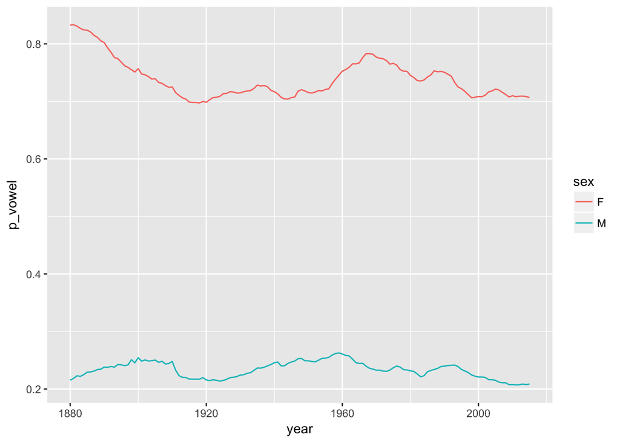

```r
babynames %>%
  mutate(last = str_sub(name, -1),
    vowel = last %in% c("a", "e", "i", "o", "u", "y")) %>%
  group_by(year, sex) %>%
  summarise(p_vowel = weighted.mean(vowel, n)) %>%
  ggplot(aes(year, p_vowel, color = sex)) +
geom_line()
```

## Your Turn 3

Repeat the previous exercise, some of whose code is below, to make a sensible graph of average TV consumption by marital status.

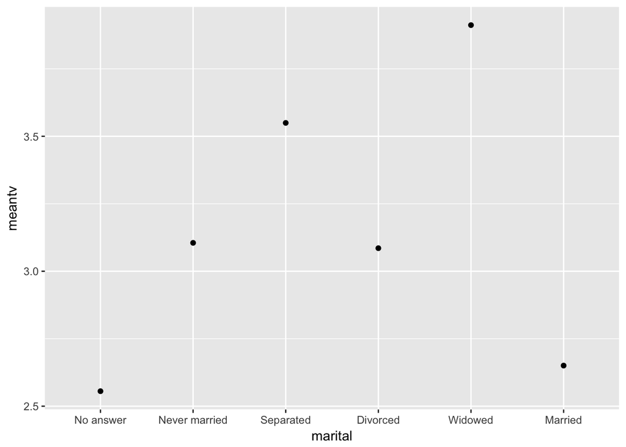

```r
library(forcats)
gss_cat %>%
  drop_na(tvhours) %>%
  group_by(marital) %>%
  summarise(meantv=mean(tvhours)) %>%
  ggplot() +
    geom_point(mapping = aes(x = marital, y = meantv))
```

## Your Turn 4

Do you think liberals or conservatives watch more TV? Compute average tv hours by party ID an then plot the results.

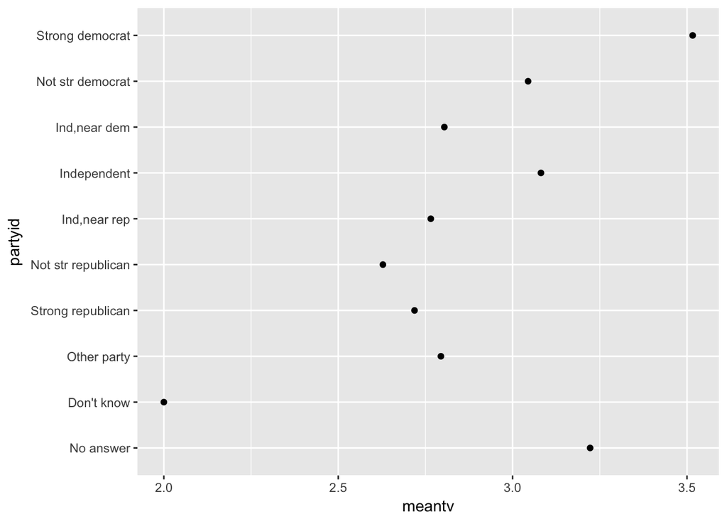

```r
library(forcats)
gss_cat %>%
  drop_na(tvhours) %>%
  group_by(partyid) %>%
  summarise(meantv=mean(tvhours)) %>%
  ggplot() +
    geom_point(mapping = aes(x =meantv , y = partyid))
```

## Your Turn 5

What is the best time of day to fly?

Use the `hour` and `minute` variables in `flights` to compute the time of day for each flight as an hms. Then use a smooth line to plot the relationship between time of day and `arr_delay`.

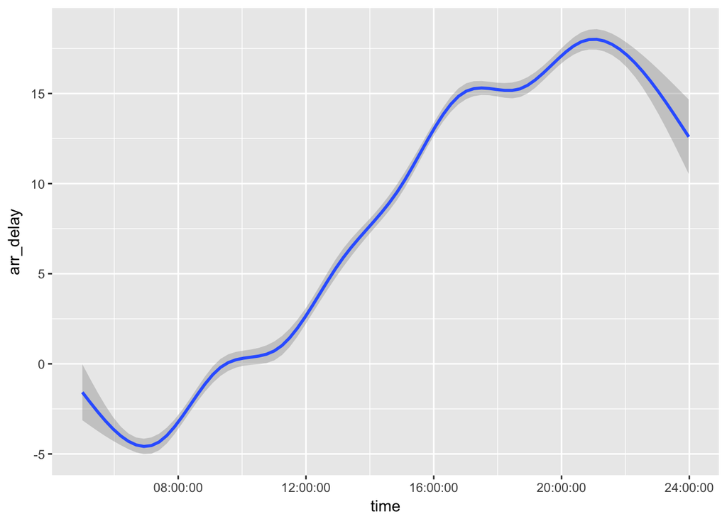

```r
data("flights")
flights %>%
  mutate(time = hms::hms(hour = hour, minute = minute)) %>%
  ggplot(aes(time, arr_delay)) + geom_smooth()
```

## Your Turn 6

Fill in the blanks to:

Extract the day of the week of each flight (as a full name) from `time_hour`.

Calculate the average `dep_delay` by day of the week.

Plot the results as a column chart (bar chart) with `geom_col()`.

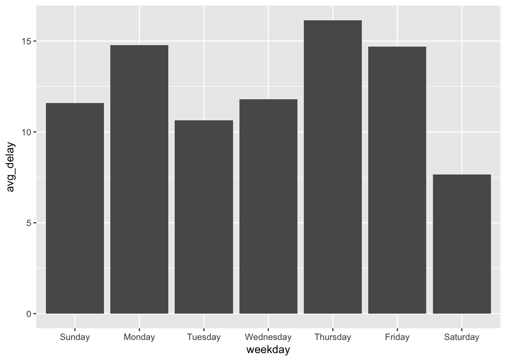

```r
flights %>%
  mutate(weekday = wday(time_hour, label = TRUE, abbr = FALSE)) %>%
  group_by(weekday) %>%
  drop_na(dep_delay) %>%
  summarise(avg_delay = mean(dep_delay)) %>%
  ggplot() +
    geom_col(mapping = aes(x = weekday, y = avg_delay))
```

# Take Aways

Dplyr gives you three *general* functions for manipulating data: `mutate()`, `summarise()`, and `group_by()`. Augment these with functions from the packages below, which focus on specific types of data.

| Package | Data Type |
| --- | --- |
| stringr | strings |
| forcats | factors |
| hms | times |
| lubridate | dates and times |